# IBM HR Analytics Employee Attrition & Performance

```python
import pandas as pd
import numpy as np
import seaborn as sns
import scipy as sp
import matplotlib.pyplot as plt
import statsmodels.api as sm
from math import sqrt
from scipy.stats import shapiro
from sklearn.linear_model import LinearRegression
from statsmodels.graphics.gofplots import qqplot
```

# Exploratory Analysis

```python
attrition = pd.read_csv(r"C:\Users\Aasna\OneDrive\Desktop\Business Analytics\ANA 1005\IBM_HR_Employee_Attrition.csv")

# display all columns
pd.set_option('display.max_columns', None)
```

```python
attrition.head()
```

|  | Age | Attrition | BusinessTravel | DailyRate | Department | DistanceFromHome | Education | EducationField | EmployeeCount | EmployeeNumber | EnvironmentSatisfaction | Gender | HourlyRate | JobInvolvement | JobLevel | JobRole | JobSatisfaction | MaritalStatus | MonthlyIncome | MonthlyRate | NumCompaniesWorked | Over18 | OverTime | PercentSalaryHike | PerformanceRating | RelationshipSatisfaction | StandardHours | StockOptionLevel | TotalWorkingYears | … |
| --- | --- | --- | --- | --- | --- | --- | --- | --- | --- | --- | --- | --- | --- | --- | --- | --- | --- | --- | --- | --- | --- | --- | --- | --- | --- | --- | --- | --- | --- | --- |
| 0 | 41 | Yes | Travel_Rarely | 1102 | Sales | 1 | 2 | Life Sciences | 1 | 1 | 2 | Female | 94 | 3 | 2 | Sales Executive | 4 | Single | 5993.0 | 19479.0 | 8 | Y | Yes | 11.0 | 3 | 1 | 80 | 0 | 8 | … |
| 1 | 49 | No | Travel_Frequently | 279 | Research & Development | 8 | 1 | Life Sciences | 1 | 2 | 3 | Male | 61 | 2 | 2 | Research Scientist | 2 | Married | 5130.0 | 24907.0 | 1 | Y | No | 23.0 | 4 | 4 | 80 | 1 | 10 | … |
| 2 | 37 | Yes | Travel_Rarely | 1373 | Research & Development | 2 | 2 | Other | 1 | 4 | 4 | Male | 92 | 2 | 1 | Laboratory Technician | 3 | Single | 2090.0 | 2396.0 | 6 | Y | Yes | 15.0 | 3 | 2 | 80 | 0 | 7 | … |
| 3 | 33 | No | Travel_Frequently | 1392 | Research & Development | 3 | 4 | Life Sciences | 1 | 5 | 4 | Female | 56 | 3 | 1 | Research Scientist | 3 | Married | 2909.0 | 23159.0 | 1 | Y | Yes | NaN | 3 | 3 | 80 | 0 | 8 | … |
| 4 | 27 | No | Travel_Rarely | 591 | Research & Development | 2 | 1 | Medical | 1 | 7 | 1 | Male | 40 | 3 | 1 | Laboratory Technician | 2 | Married | 3468.0 | 16632.0 | 9 | Y | No | 12.0 | 3 | 4 | 80 | 1 | 6 | … |

```python
attrition.info()
```

```
<class 'pandas.core.frame.DataFrame'>
RangeIndex: 1470 entries, 0 to 1469
Data columns (total 35 columns):
 #   Column                    Non-Null Count  Dtype
---  ------                    --------------  -----
 0   Age                       1470 non-null   int64
 1   Attrition                 1470 non-null   object
 2   BusinessTravel            1470 non-null   object
 3   DailyRate                 1470 non-null   int64
 4   Department                1470 non-null   object
 5   DistanceFromHome          1470 non-null   int64
 6   Education                 1470 non-null   int64
 7   EducationField            1470 non-null   object
 8   EmployeeCount             1470 non-null   int64
 9   EmployeeNumber            1470 non-null   int64
```

[output cut: 27 more lines]

```python
attrition.dtypes
```

```
Age                           int64
Attrition                    object
BusinessTravel               object
DailyRate                     int64
Department                   object
DistanceFromHome              int64
Education                     int64
EducationField               object
EmployeeCount                 int64
EmployeeNumber                int64
EnvironmentSatisfaction       int64
Gender                       object
HourlyRate                    int64
JobInvolvement                int64
JobLevel                      int64
JobRole                      object
JobSatisfaction               int64
MaritalStatus                object
MonthlyIncome               float64
MonthlyRate                 float64
NumCompaniesWorked            int64
Over18                       object
OverTime                     object
PercentSalaryHike           float64
PerformanceRating             int64
RelationshipSatisfaction      int64
StandardHours                 int64
StockOptionLevel              int64
TotalWorkingYears             int64
TrainingTimesLastYear         int64
WorkLifeBalance               int64
YearsAtCompany                int64
YearsInCurrentRole            int64
YearsSinceLastPromotion       int64
YearsWithCurrManager          int64
dtype: object
```

```python
attrition.isnull().sum()
```

```
Age                          0
Attrition                    0
BusinessTravel               0
DailyRate                    0
Department                   0
DistanceFromHome             0
Education                    0
EducationField               0
EmployeeCount                0
EmployeeNumber               0
EnvironmentSatisfaction      0
Gender                       0
HourlyRate                   0
JobInvolvement               0
JobLevel                     0
JobRole                      0
JobSatisfaction              0
MaritalStatus                0
MonthlyIncome               22
MonthlyRate                 17
NumCompaniesWorked           0
Over18                       0
OverTime                     0
PercentSalaryHike           28
PerformanceRating            0
RelationshipSatisfaction     0
StandardHours                0
StockOptionLevel             0
TotalWorkingYears            0
TrainingTimesLastYear        0
WorkLifeBalance              0
YearsAtCompany               0
YearsInCurrentRole           0
YearsSinceLastPromotion      0
YearsWithCurrManager         0
dtype: int64
```

```python
attrition.describe()
```

|  | Age | DailyRate | DistanceFromHome | Education | EmployeeCount | EmployeeNumber | EnvironmentSatisfaction | HourlyRate | JobInvolvement | JobLevel | JobSatisfaction | MonthlyIncome | MonthlyRate | NumCompaniesWorked | PercentSalaryHike | PerformanceRating | RelationshipSatisfaction | StandardHours | StockOptionLevel | TotalWorkingYears | TrainingTimesLastYear | WorkLifeBalance | YearsAtCompany | YearsInCurrentRole | YearsSinceLastPromotion | YearsWithCurrManager |
| --- | --- | --- | --- | --- | --- | --- | --- | --- | --- | --- | --- | --- | --- | --- | --- | --- | --- | --- | --- | --- | --- | --- | --- | --- | --- | --- |
| count | 1470.000000 | 1470.000000 | 1470.000000 | 1470.000000 | 1470.0 | 1470.000000 | 1470.000000 | 1470.000000 | 1470.000000 | 1470.000000 | 1470.000000 | 1448.000000 | 1453.000000 | 1470.000000 | 1442.000000 | 1470.000000 | 1470.000000 | 1470.0 | 1470.000000 | 1470.000000 | 1470.000000 | 1470.000000 | 1470.000000 | 1470.000000 | 1470.000000 | 1470.000000 |
| mean | 36.923810 | 802.485714 | 9.192517 | 2.912925 | 1.0 | 1024.865306 | 2.721769 | 65.891156 | 2.729932 | 2.063946 | 2.728571 | 6579.797652 | 14430.821060 | 2.693197 | 15.217753 | 3.153741 | 2.712245 | 80.0 | 0.793878 | 11.279592 | 2.799320 | 2.761224 | 7.008163 | 4.229252 | 2.187755 | 4.123129 |
| std | 9.135373 | 403.509100 | 8.106864 | 1.024165 | 0.0 | 602.024335 | 1.093082 | 20.329428 | 0.711561 | 1.106940 | 1.102846 | 4760.212344 | 7140.435534 | 2.498009 | 3.659106 | 0.360824 | 1.081209 | 0.0 | 0.852077 | 7.780782 | 1.289271 | 0.706476 | 6.126525 | 3.623137 | 3.222430 | 3.568136 |
| min | 18.000000 | 102.000000 | 1.000000 | 1.000000 | 1.0 | 1.000000 | 1.000000 | 30.000000 | 1.000000 | 1.000000 | 1.000000 | 898.000000 | 673.000000 | 0.000000 | 11.000000 | 3.000000 | 1.000000 | 80.0 | 0.000000 | 0.000000 | 0.000000 | 1.000000 | 0.000000 | 0.000000 | 0.000000 | 0.000000 |
| 25% | 30.000000 | 465.000000 | 2.000000 | 2.000000 | 1.0 | 491.250000 | 2.000000 | 48.000000 | 2.000000 | 1.000000 | 2.000000 | 2972.750000 | 8269.000000 | 1.000000 | 12.000000 | 3.000000 | 2.000000 | 80.0 | 0.000000 | 6.000000 | 2.000000 | 2.000000 | 3.000000 | 2.000000 | 0.000000 | 2.000000 |
| 50% | 36.000000 | 802.000000 | 7.000000 | 3.000000 | 1.0 | 1020.500000 | 3.000000 | 66.000000 | 3.000000 | 2.000000 | 3.000000 | 4973.500000 | 14293.000000 | 2.000000 | 14.000000 | 3.000000 | 3.000000 | 80.0 | 1.000000 | 10.000000 | 3.000000 | 3.000000 | 5.000000 | 3.000000 | 1.000000 | 3.000000 |
| 75% | 43.000000 | 1157.000000 | 14.000000 | 4.000000 | 1.0 | 1555.750000 | 4.000000 | 83.750000 | 3.000000 | 3.000000 | 4.000000 | 8450.250000 | 20520.000000 | 4.000000 | 18.000000 | 3.000000 | 4.000000 | 80.0 | 1.000000 | 15.000000 | 3.000000 | 3.000000 | 9.000000 | 7.000000 | 3.000000 | 7.000000 |
| max | 60.000000 | 1499.000000 | 29.000000 | 5.000000 | 1.0 | 2068.000000 | 4.000000 | 100.000000 | 4.000000 | 5.000000 | 4.000000 | 25999.000000 | 40675.000000 | 9.000000 | 25.000000 | 4.000000 | 4.000000 | 80.0 | 3.000000 | 40.000000 | 6.000000 | 4.000000 | 40.000000 | 18.000000 | 15.000000 | 17.000000 |

```python
attrition.shape
```

```
(1470, 35)
```

# Data Cleaning

### Dropping Columns

```python
# Standard hours and employee count are not nessessary for our analysis. We will drop these columns
attrition.drop(['StandardHours', 'EmployeeCount'], axis=1, inplace=True)
```

### Correcting Errors in Categorical Variables

Inspecting the data we observed that variables Department and JobRole appear to have errors that are resulting in redundancies.

```python
attrition['Department'].unique()
```

```
array(['Sales', 'Research & Development', 'R&D', 'Human Resources'],
      dtype=object)
```

```python
attrition.replace('R&D', 'Research & Development', inplace=True)
```

```python
# Check unique departments again
attrition['Department'].unique()
```

```
array(['Sales', 'Research & Development', 'Human Resources'], dtype=object)
```

```python
attrition['JobRole'].unique()
```

```
array(['Sales Executive', 'Research Scientist', 'Laboratory Technician',
       'Manufacturing Director', 'Healthcare Representative', 'Manager',
       'Sales Representative', 'Research Director',
       'Health care Representative', 'Human Resources'], dtype=object)
```

Looking at the JobRole variable, we noticed there were redundant values as well. 'Health care Representative' and 'Healthcare Representative' mean the same, so we will update each instance to 'Healthcare Representative'.

```python
attrition.replace('Health care Representative', 'Healthcare Representative', inplace=True)

# Check unique departments again
attrition['JobRole'].unique()
```

```
array(['Sales Executive', 'Research Scientist', 'Laboratory Technician',
       'Manufacturing Director', 'Healthcare Representative', 'Manager',
       'Sales Representative', 'Research Director', 'Human Resources'],
      dtype=object)
```

### Correcting Data Types

Based on our use of this data and the corresponding analysis, there are a number of variables that should be converted into other data types. This includes Age, Education, EmployeeNumber, EnvironmentSatisfaction, JobInvolvement, JobLevel, JobSatisfaction, PerformanceRating, RelationshipSatisfaction, WorkLifeBalance, and StockOptionLevel.

```python
# Modify data types
cols_to_update = ['Age', 'Education', 'EmployeeNumber', 'EnvironmentSatisfaction', 'JobInvolvement',
           'JobLevel', 'JobSatisfaction', 'PerformanceRating', 'RelationshipSatisfaction',
           'WorkLifeBalance', 'StockOptionLevel']

for col in cols_to_update:
    attrition[col] = attrition[col].astype('object')

# Check data types again
attrition.dtypes
```

```
Age                          object
Attrition                    object
BusinessTravel               object
DailyRate                     int64
Department                   object
DistanceFromHome              int64
Education                    object
EducationField               object
EmployeeNumber               object
EnvironmentSatisfaction      object
Gender                       object
HourlyRate                    int64
JobInvolvement               object
JobLevel                     object
JobRole                      object
JobSatisfaction              object
MaritalStatus                object
MonthlyIncome               float64
MonthlyRate                 float64
NumCompaniesWorked            int64
Over18                       object
OverTime                     object
PercentSalaryHike           float64
PerformanceRating            object
RelationshipSatisfaction     object
StockOptionLevel             object
TotalWorkingYears             int64
TrainingTimesLastYear         int64
WorkLifeBalance              object
YearsAtCompany                int64
YearsInCurrentRole            int64
YearsSinceLastPromotion       int64
YearsWithCurrManager          int64
dtype: object
```

# Imputation Methods

```python
# Calculate the proportion of missing values for the MonthlyRate column
prop_missing_monthly_rates = (attrition['MonthlyRate'].isnull().sum() / attrition.shape[0]) * 100
prop_missing_monthly_rates
```

```
1.1564625850340136
```

```
0.04949563154705119
```

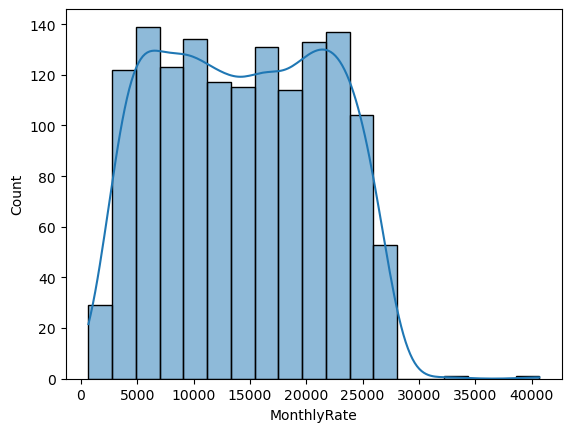

```python
# Also check the skewness of the monthly rate distribution
# Check if the values in the monthly rate column are skewed first
print(attrition['MonthlyRate'].skew())
# Skewness value is very low at 0.04949563154705119.

# Visualize this using a histogram
sns.histplot(attrition['MonthlyRate'], kde=True)
```

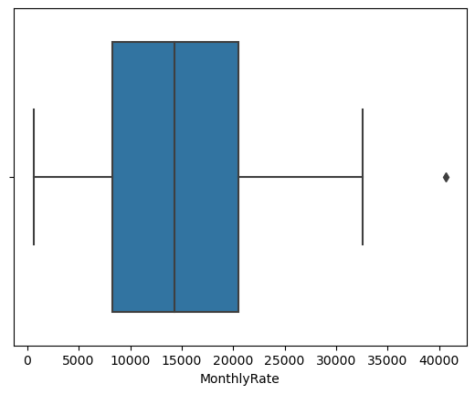

```python
# Boxplot
sns.boxplot(attrition['MonthlyRate'])
```

```python
# Find a missing value to check after imputation
attrition[attrition['MonthlyRate'].isnull()]
# Notice row 115 has a missing value for MonthlyRate.
# We will check this value after performing the imputation.
```

|  | Age | Attrition | BusinessTravel | DailyRate | Department | DistanceFromHome | Education | EducationField | EmployeeNumber | EnvironmentSatisfaction | Gender | HourlyRate | JobInvolvement | JobLevel | JobRole | JobSatisfaction | MaritalStatus | MonthlyIncome | MonthlyRate | NumCompaniesWorked | Over18 | OverTime | PercentSalaryHike | PerformanceRating | RelationshipSatisfaction | StockOptionLevel | TotalWorkingYears | TrainingTimesLastYear | WorkLifeBalance | … |
| --- | --- | --- | --- | --- | --- | --- | --- | --- | --- | --- | --- | --- | --- | --- | --- | --- | --- | --- | --- | --- | --- | --- | --- | --- | --- | --- | --- | --- | --- | --- |
| 115 | 37 | No | Travel_Rarely | 1189 | Sales | 3 | 3 | Life Sciences | 152 | 3 | Male | 87 | 3 | 3 | Sales Executive | 4 | Single | 7428.0 | NaN | 2 | Y | No | 12.0 | 3 | 1 | 0 | 12 | 3 | 3 | … |
| 427 | 60 | No | Travel_Frequently | 1499 | Sales | 28 | 3 | Marketing | 573 | 3 | Female | 80 | 2 | 3 | Sales Executive | 1 | Married | 10266.0 | NaN | 4 | Y | No | 19.0 | 3 | 4 | 0 | 22 | 5 | 4 | … |
| 489 | 43 | No | Travel_Rarely | 782 | Research & Development | 6 | 4 | Other | 661 | 2 | Male | 50 | 2 | 4 | Research Director | 4 | Divorced | 16627.0 | NaN | 4 | Y | Yes | 14.0 | 3 | 3 | 1 | 21 | 3 | 2 | … |
| 490 | 38 | No | Travel_Rarely | 362 | Research & Development | 1 | 1 | Life Sciences | 662 | 3 | Female | 43 | 3 | 1 | Research Scientist | 1 | Single | 2619.0 | NaN | 3 | Y | No | 17.0 | 3 | 4 | 0 | 8 | 3 | 2 | … |
| 494 | 34 | No | Travel_Rarely | 204 | Sales | 14 | 3 | Technical Degree | 666 | 3 | Female | 31 | 3 | 1 | Sales Representative | 3 | Divorced | 2579.0 | NaN | 1 | Y | Yes | 18.0 | 3 | 4 | 2 | 8 | 3 | 3 | … |
| 613 | 34 | No | Travel_Rarely | 829 | Human Resources | 3 | 2 | Human Resources | 847 | 3 | Male | 88 | 3 | 1 | Human Resources | 4 | Married | 3737.0 | NaN | 0 | Y | No | 19.0 | 3 | 3 | 1 | 4 | 1 | 1 | … |
| 623 | 30 | No | Travel_Frequently | 1012 | Research & Development | 5 | 4 | Life Sciences | 861 | 2 | Male | 75 | 2 | 1 | Research Scientist | 4 | Divorced | 3761.0 | NaN | 9 | Y | No | 12.0 | 3 | 2 | 1 | 10 | 3 | 2 | … |
| 798 | 33 | Yes | Travel_Rarely | 1017 | Research & Development | 25 | 3 | Medical | 1108 | 1 | Male | 55 | 2 | 1 | Research Scientist | 2 | Single | 2313.0 | NaN | 4 | Y | Yes | 20.0 | 4 | 2 | 0 | 5 | 0 | 3 | … |
| 825 | 29 | No | Travel_Rarely | 718 | Research & Development | 8 | 1 | Medical | 1150 | 2 | Male | 79 | 2 | 2 | Manufacturing Director | 4 | Married | 5056.0 | NaN | 1 | Y | Yes | 15.0 | 3 | 3 | 1 | 10 | 2 | 2 | … |
| 913 | 45 | Yes | Travel_Rarely | 1449 | Sales | 2 | 3 | Marketing | 1277 | 1 | Female | 94 | 1 | 5 | Manager | 2 | Single | 18824.0 | NaN | 2 | Y | Yes | 16.0 | 3 | 1 | 0 | 26 | 2 | 3 | … |
| 927 | 36 | No | Travel_Rarely | 429 | Research & Development | 2 | 4 | Life Sciences | 1294 | 3 | Female | 53 | 3 | 2 | Manufacturing Director | 2 | Single | 5410.0 | NaN | 9 | Y | Yes | 11.0 | 3 | 4 | 0 | 18 | 2 | 3 | … |
| 1049 | 30 | No | Travel_Rarely | 1358 | Sales | 16 | 1 | Life Sciences | 1479 | 4 | Male | 96 | 3 | 2 | Sales Executive | 3 | Married | 5301.0 | NaN | 8 | Y | No | 15.0 | 3 | 3 | 2 | 4 | 2 | 2 | … |
| 1245 | 24 | No | Travel_Frequently | 897 | Human Resources | 10 | 3 | Medical | 1746 | 1 | Male | 59 | 3 | 1 | Human Resources | 4 | Married | 2145.0 | NaN | 0 | Y | No | 14.0 | 3 | 4 | 1 | 3 | 2 | 3 | … |
| 1249 | 29 | Yes | Travel_Rarely | 428 | Sales | 9 | 3 | Marketing | 1752 | 2 | Female | 52 | 1 | 1 | Sales Representative | 2 | Single | 2760.0 | NaN | 1 | Y | No | 13.0 | 3 | 3 | 0 | 2 | 3 | 3 | … |
| 1305 | 54 | No | Travel_Rarely | 431 | Research & Development | 7 | 4 | Medical | 1830 | 4 | Female | 68 | 3 | 2 | Research Scientist | 4 | Married | 6854.0 | NaN | 4 | Y | No | 15.0 | 3 | 2 | 1 | 14 | 2 | 2 | … |
| 1387 | 29 | No | Travel_Rarely | 136 | Research & Development | 1 | 3 | Life Sciences | 1954 | 1 | Male | 89 | 3 | 2 | Healthcare Representative | 1 | Married | 5373.0 | NaN | 0 | Y | No | 12.0 | 3 | 1 | 1 | 6 | 5 | 2 | … |
| 1455 | 40 | No | Travel_Rarely | 1322 | Research & Development | 2 | 4 | Life Sciences | 2048 | 3 | Male | 52 | 2 | 1 | Research Scientist | 3 | Single | 2809.0 | NaN | 2 | Y | No | 14.0 | 3 | 4 | 0 | 8 | 2 | 3 | … |

```python
# Perform the median imputation
median_monthly_rate = attrition['MonthlyRate'].median()
# Note, median function ignores null values by default. No need to exclude them from the calculation.
# The median monthly rate is 14293 for all employees.

# Impute the missing values with the median of the monthly rate column.
attrition['MonthlyRate'] = attrition['MonthlyRate'].fillna(median_monthly_rate)
```

```python
# Check null values for MonthlyRate variable
attrition['MonthlyRate'].isnull().sum()
# There are no null values left for this variable.
```

```
0
```

```python
# Verify the imputation worked as expected (filled NA values with median of Monthly rate column)
attrition[attrition['MonthlyRate'].isnull()]

# Check the monthly rate in row 115
attrition.iloc[115]['MonthlyRate']

# Notice the monthly rate for this row is 14293, which aligns with the median monthly rate for all IBM employees.
# Thus, the imputation worked as expected.
```

```
14293.0
```

### Linear Regression Imputation

There are still other columns that have missing values, those being MonthlyIncome and PercentSalaryHike. When deciding which method to use for each, it will be helpful to check the correlation coefficients for each variable to determine if linear regression would be an approproate approach or not.

```python
# Check correlation coefficients between every variable in dataset
attrition.corr()
```

|  | DailyRate | DistanceFromHome | HourlyRate | MonthlyIncome | MonthlyRate | NumCompaniesWorked | PercentSalaryHike | TotalWorkingYears | TrainingTimesLastYear | YearsAtCompany | YearsInCurrentRole | YearsSinceLastPromotion | YearsWithCurrManager |
| --- | --- | --- | --- | --- | --- | --- | --- | --- | --- | --- | --- | --- | --- |
| DailyRate | 1.000000 | -0.004985 | 0.023381 | 0.012911 | -0.028673 | 0.038153 | 0.021180 | 0.014515 | 0.002453 | -0.034055 | 0.009932 | -0.033229 | -0.026363 |
| DistanceFromHome | -0.004985 | 1.000000 | 0.031131 | -0.013991 | 0.027881 | -0.029251 | 0.039438 | 0.004628 | -0.036942 | 0.009508 | 0.018845 | 0.010029 | 0.014406 |
| HourlyRate | 0.023381 | 0.031131 | 1.000000 | -0.012635 | -0.010837 | 0.022157 | -0.008933 | -0.002334 | -0.008548 | -0.019582 | -0.024106 | -0.026716 | -0.020123 |
| MonthlyIncome | 0.012911 | -0.013991 | -0.012635 | 1.000000 | 0.036367 | 0.146732 | -0.028208 | 0.770645 | -0.023122 | 0.507083 | 0.356648 | 0.341395 | 0.334872 |
| MonthlyRate | -0.028673 | 0.027881 | -0.010837 | 0.036367 | 1.000000 | 0.020152 | -0.011650 | 0.023122 | 0.003281 | -0.025130 | -0.015288 | -0.000301 | -0.035994 |
| NumCompaniesWorked | 0.038153 | -0.029251 | 0.022157 | 0.146732 | 0.020152 | 1.000000 | -0.009349 | 0.237639 | -0.066054 | -0.118421 | -0.090754 | -0.036814 | -0.110319 |
| PercentSalaryHike | 0.021180 | 0.039438 | -0.008933 | -0.028208 | -0.011650 | -0.009349 | 1.000000 | -0.024377 | -0.000119 | -0.036474 | -0.005048 | -0.017826 | -0.016092 |
| TotalWorkingYears | 0.014515 | 0.004628 | -0.002334 | 0.770645 | 0.023122 | 0.237639 | -0.024377 | 1.000000 | -0.035662 | 0.628133 | 0.460365 | 0.404858 | 0.459188 |
| TrainingTimesLastYear | 0.002453 | -0.036942 | -0.008548 | -0.023122 | 0.003281 | -0.066054 | -0.000119 | -0.035662 | 1.000000 | 0.003569 | -0.005738 | -0.002067 | -0.004096 |
| YearsAtCompany | -0.034055 | 0.009508 | -0.019582 | 0.507083 | -0.025130 | -0.118421 | -0.036474 | 0.628133 | 0.003569 | 1.000000 | 0.758754 | 0.618409 | 0.769212 |
| YearsInCurrentRole | 0.009932 | 0.018845 | -0.024106 | 0.356648 | -0.015288 | -0.090754 | -0.005048 | 0.460365 | -0.005738 | 0.758754 | 1.000000 | 0.548056 | 0.714365 |
| YearsSinceLastPromotion | -0.033229 | 0.010029 | -0.026716 | 0.341395 | -0.000301 | -0.036814 | -0.017826 | 0.404858 | -0.002067 | 0.618409 | 0.548056 | 1.000000 | 0.510224 |
| YearsWithCurrManager | -0.026363 | 0.014406 | -0.020123 | 0.334872 | -0.035994 | -0.110319 | -0.016092 | 0.459188 | -0.004096 | 0.769212 | 0.714365 | 0.510224 | 1.000000 |

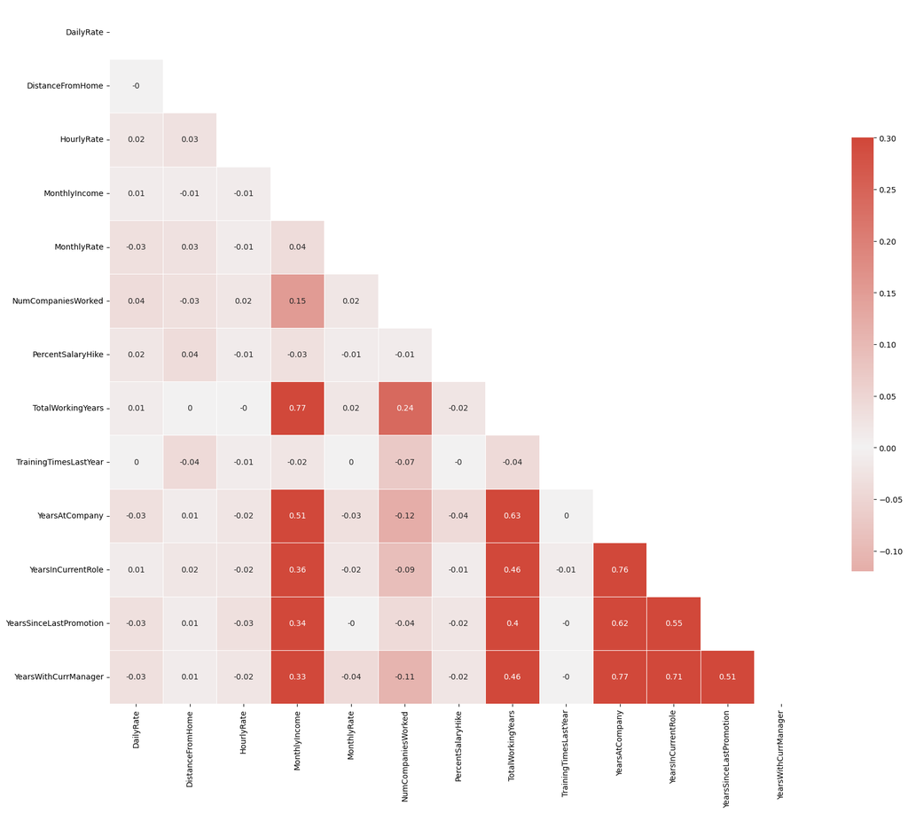

```python
# Visualize these correlations in a heatmap
# Get correlation matrix
cormatrix = attrition.corr().round(2)
cormatrix

# Generate a mask to cover the upper triangle
mask = np.triu(np.ones_like(cormatrix, dtype=bool))

# Set up the plot to visualize the matrix in a head map
f, ax = plt.subplots(figsize = (20, 20))

# heat map from seaborn
cmap = sns.diverging_palette(15, 15, as_cmap=True)

# draw the heat map
sns.heatmap(cormatrix, mask=mask, cmap=cmap, vmax=0.3, center=0,
            square=True, linewidth=0.5, cbar_kws={"shrink":.5}, annot=True)
```

Based on the heatmap above, the high correlation can be seen in dark orange at the intersection of MonthlyIncome and TotalWorkingYears.

```python
# To ensure that TotalWorkingYears is the numerical column with the highest correlation with MonthlyIncome,
# we can view all the column coefficients with MonthlyIncome, and sort this in descending order.

# First, we must determine which columns are highly correlated with the MonthlyIncome variable
attrition.corrwith(attrition["MonthlyIncome"]).sort_values(ascending=False)

# Notice, the highest correlation coefficient and the other variable that is most correlated with MonthlyIncome
# is TotalWorkingYears at 0.77, confirming our decision above.
```

```
MonthlyIncome              1.000000
TotalWorkingYears          0.770645
YearsAtCompany             0.507083
YearsInCurrentRole         0.356648
YearsSinceLastPromotion    0.341395
YearsWithCurrManager       0.334872
NumCompaniesWorked         0.146732
MonthlyRate                0.036367
DailyRate                  0.012911
HourlyRate                -0.012635
DistanceFromHome          -0.013991
TrainingTimesLastYear     -0.023122
PercentSalaryHike         -0.028208
dtype: float64
```

```python
# Perform the Linear Regression Imputation: Missing values of MonthlyIncome and TotalWorkingYears

# Split the data by rows with non-missing and missing MonthlyIncome values
nonmissing_monthly_income = attrition[attrition['MonthlyIncome'].notnull()]
missing_monthly_income = attrition[attrition['MonthlyIncome'].isnull()]

# Initialize the linear regression model.
work_years_income_model = LinearRegression()

# Fit this model with the rows that have non-missing monthly incomes

# Consider the TotalWorkingYears variable as independent and the MonthlyIncome variable as dependent.
work_years_income_model.fit(nonmissing_monthly_income[['TotalWorkingYears']], nonmissing_monthly_income[['MonthlyIncome']])

# Predict the monthly income value for missing records using the model
monthly_income_pred = work_years_income_model.predict(missing_monthly_income[['TotalWorkingYears']])

# Impute the missing values in MonthlyIncome with the models predicted values
attrition.loc[attrition['MonthlyIncome'].isnull(),'MonthlyIncome'] = monthly_income_pred
```

```python
# Verify the imputation worked as expected
attrition['MonthlyIncome'].isnull().sum()
```

```
0
```